# The Bestseller Palette: Data-Backed Trends in Book Cover Colors

Author

Andrea Rivera & Maria Carda

Published

March 17, 2025

#Introduction

Book cover design plays a crucial role in attracting readers and influencing purchasing decisions. One key aspect of cover design is color, which conveys mood, genre conventions, and marketing strategies. This study aims to analyze the color palettes of book covers across different genres in two major online book platforms: the top-selling sections of *Casa del Libro* and compare them to *Goodreads Readers’ Favorite Books 2024*.

By examining whether specific color schemes are more prevalent in certain categories, this research seeks to uncover patterns in book cover aesthetics and their possible correlation with genre expectations and consumer preferences.

To conduct this analysis, we used R for web scraping to collect cover images from both platforms and extract dominant color palettes using image processing techniques.

# Libraries

```r
packages = c("RSelenium", "rvest", "magrittr", "tidyr", "dplyr", "magick", "tidyverse", "ggplot2", "scales", "shiny", "writexl")

package.check <- lapply(packages,
                        FUN = function(x){
                          if (!require(x,character.only = TRUE)){
                            install.packages(x,dependencies = TRUE)
                            library(x, character.only = TRUE)
                          }
                        }
)
```

# Casa del Libro

## Categories & sub-categories

```r
# Categories & Subcategories
categories <- data.frame(
  category = c("Biography", "Science Fiction", "Mystery & Thriller", "Romance", "Young Adult Fantasy"),
  category_xpath = c("//a[contains(text(),'No Ficción')]",
                     "//a[contains(text(),'Ficción')]",
                     "//a[contains(text(),'Ficción')]",
                     "//a[contains(text(),'Ficción')]",
                     "//a[contains(text(),'Juvenil')]"),
  subcategory_xpath = c("//a[contains(text(),'Biografías')]",
                        "//a[span[contains(text(),'Novela de ciencia ficción')]]",
                        "//a[span[contains(text(),'Novela negra')]]",
                        "//a[span[contains(text(),'Novela romántica y erótica')]]",
                        "//a[span[contains(text(),'Fantasía')]]")
)
```

## Selenium

```r
remDr <- remoteDriver(port = 4449)
remDr$open()
```

[output not shown]

[output cut: 19 more lines]

[output not shown]

```r
# Navegar a una página para comprobar que funciona
remDr$navigate("https://www.casadellibro.com")

Sys.sleep(5)
```

## Privacidad

```r
# Intenta encontrar el botón de rechazar, si no lo encuentra, no hace nada
tryCatch({
  # Intenta encontrar el botón de rechazar en la ventana de privacidad
  rechazar <- remDr$findElement(using = "xpath", "//button[@id='onetrust-reject-all-handler']")

  # Si el botón se encuentra, hacer clic en él
  rechazar$clickElement()
}, error = function(e) {
  # Si ocurre un error (por ejemplo, si no se encuentra el elemento), no hacer nada
  message("No se encontró la ventana de privacidad o el botón de rechazar")
})
```

## Scrapbook

### Function

```r
# Función de scrapbooks (como la que ya tienes)
scrap_books <- function(category_xpath, subcategory_xpath, category_name, num_pages = 10) {

  # Hacer clic en la categoría
  enlace <- remDr$findElement(using = "xpath", category_xpath)
  enlace$clickElement()

  # Hacer clic en la subcategoría
  Sys.sleep(5)  # Esperar a que la página cargue
  enlace <- remDr$findElement(using = "xpath", subcategory_xpath)
  enlace$clickElement()

  # Crear listas vacías para almacenar los datos
  all_titles <- c()
  all_authors <- c()
  all_img_urls <- c()

  # Extraer datos de las primeras n páginas
  for (i in 1:num_pages) {

    Sys.sleep(5)  # Espera para que la página cargue

    # Extraer los elementos de productos
    product_elems <- remDr$findElements(using = "css selector", "div.compact-product")
    product_html <- sapply(product_elems, function(x) x$getElementAttribute("outerHTML")[[1]])
    parsed_products <- lapply(product_html, read_html)

    # Extraer Títulos
    titles <- sapply(parsed_products, function(x) x %>% html_node("a.product-title") %>% html_text())

    # Extraer Autores
    authors <- sapply(parsed_products, function(x) {
      author_node <- x %>% html_node("p.truncate-text")
      if (!is.null(author_node)) html_text(author_node) else NA
    })

    # Extraer URLs de las imágenes
    img_urls <- sapply(parsed_products, function(x) {
      x %>% html_node("img") %>% html_attr("src")
    })

    # Guardar en listas
    all_titles <- c(all_titles, titles)
    all_authors <- c(all_authors, authors)
    all_img_urls <- c(all_img_urls, img_urls)

    # Pasar a la siguiente página
    boton_pagina <- tryCatch({
      remDr$findElement(using = "xpath", paste0("//button[normalize-space(text())='", i + 1, "']"))
    }, error = function(e) NULL)

    if (!is.null(boton_pagina)) {
      boton_pagina$clickElement()
      Sys.sleep(5)  # Esperar a que cargue la nueva página
      remDr$refresh()  # Refrescar el DOM
    } else {
      message("Botón de página ", i + 1, " no encontrado.")
      break
    }
  }

  # Crear dataframe con los datos
  result <- data.frame(
    category = category_name,
    title = all_titles,
    author = all_authors,
    img_url = all_img_urls,
    stringsAsFactors = FALSE
  )

  return(result)
}
```

### Application

```r
# Iterar sobre las categorías y scrapear cada una
temp_casa.libro <- list()

for (i in 1:nrow(categories)) {
  books <- scrap_books(
    category_xpath = categories$category_xpath[i],
    subcategory_xpath = categories$subcategory_xpath[i],
    category_name = categories$category[i]
  )

  temp_casa.libro[[categories$category[i]]] <- books
}
```

### Save results

```r
# Guardar resultados
casa.libro <- do.call(rbind, temp_casa.libro)
```

## End selenium

```r
# Finalizar Selenium
remDr$close()
```

## Extract colors

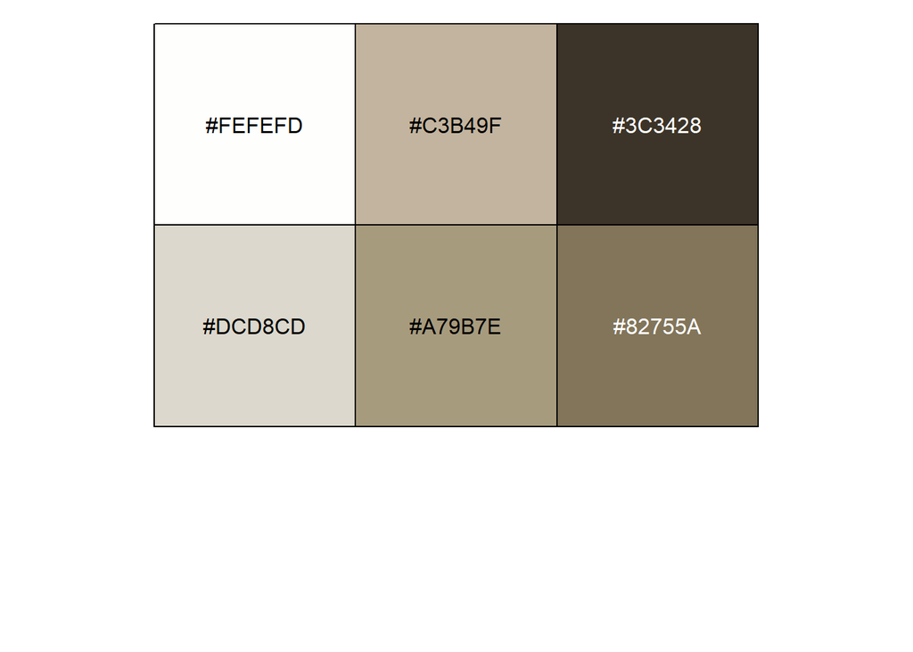

```r
# Modificar la función extract_colors para adaptarse a un dataframe
extract_colors <- function(image_url, n_colors = 6) {
  # Leer la imagen desde la URL
  img <- image_read(image_url) %>%
    image_resize("50x50") # Redimensionar para reducir el tiempo de procesamiento

  # Convertir la imagen a datos de píxeles
  img_data <- image_data(img)

  # Verificar si la estructura de img_data es un bitmap
  if (inherits(img_data, "bitmap")) {
    # Si es un bitmap, lo convertimos a un formato numérico
    img_data <- as.integer(img_data) / 255
  }

  # Convertir la imagen a una data.frame
  # Extraemos los canales RGB
  df <- data.frame(
    red = as.vector(img_data[,,1]),    # Canal rojo
    green = as.vector(img_data[,,2]),  # Canal verde
    blue = as.vector(img_data[,,3])    # Canal azul
  )

  # Aplicar k-means para encontrar los colores dominantes
  kmeans_result <- kmeans(df, centers = n_colors, nstart = 25, iter.max = 100)

  # Convertir los colores dominantes a formato RGB
  dominant_colors <- rgb(kmeans_result$centers[,1],
                         kmeans_result$centers[,2],
                         kmeans_result$centers[,3], maxColorValue = 1)

  # Devolver los colores como un vector de colores (no como lista)
  return(dominant_colors)
}

# Aplicar la función a cada imagen en el dataframe, devolviendo una lista de colores por imagen
casa.libro$colors <- sapply(casa.libro$img_url, extract_colors, simplify = FALSE)

# Mostrar los colores del ID 1
show_col(casa.libro$colors[[1]])
```

# Goodreads

Goodreads is an online platform that connects readers worldwide. It offers features such as book reviews, ratings, and personalized recommendations, fostering a vibrant community for book enthusiasts. This includes the *Goodreads Choice Awards*, annual recognitions of the year’s most popular books across various genres that are chosen by the platform’s users.

For this research, we scraped the results of the 2024 awards, which established a record-breaking number of user votes (6.2 million). The selected categories to match as close as possible Casa del Libro were the following:

- Mystery and Thriller books
- Romance books
- Science Fiction books
- History and Biography books
- Young adult fantasy books

## Scrapping

The first step is to define the URLs that need to be scrapped and create an empty dataframe where the data will be stored.

Then, a loop is created to go through each URL, retrieving the book titles, cover image URLs, and category names. The extracted category name is cleaned by removing the prefix “Readers’ Favorite” and book details are stored in a temporary data frame, which is then appended to the main goodreads data frame.

```r
url <- "https://www.goodreads.com/choiceawards/readers-favorite-mystery-thriller-books-2024"
url2 <- "https://www.goodreads.com/choiceawards/readers-favorite-romance-books-2024"
url3 <- "https://www.goodreads.com/choiceawards/readers-favorite-ya-fantasy-books-2024"
url4 <- "https://www.goodreads.com/choiceawards/readers-favorite-science-fiction-books-2024"
url5 <- "https://www.goodreads.com/choiceawards/readers-favorite-history-bio-books-2024"
urls <- c(url, url2, url3, url4, url5)

goodreads <- data.frame()

## Loop to extract the data
for (url in urls) {
    page <- read_html(url)

    # Extract book titles
    titles <- page %>%
        html_nodes(".pollAnswer__bookLink img") %>%
        html_attr("alt")

    # Extract cover images
    covers <- page %>%
        html_nodes(".pollAnswer__bookLink img") %>%
        html_attr("src")

    # Extract category from the HTML
    category <- page %>%
        html_element(".gcaMastheader") %>%
        html_text() %>%
        gsub("Readers' Favorite ", "", .)

    # Create a temporary data frame
    temp_books <- data.frame(title = titles, img_url = covers, category = category, stringsAsFactors = FALSE)

    # Append to the main data frame
    goodreads <- bind_rows(goodreads, temp_books)
}
```

After collecting the book information, we extracted the book title and author separately using regular expressions. We also employed the previously defined function *extract_colors* to obtain color palettes from the book cover images.

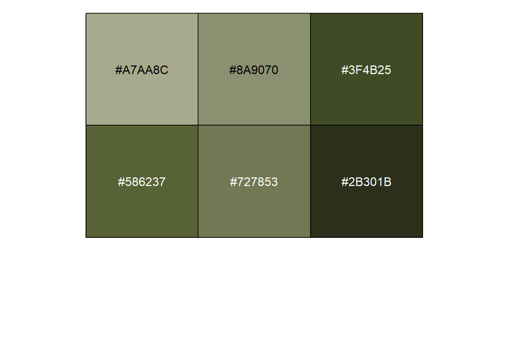

```r
# Use general expression to separate title and author
goodreads <- goodreads %>%
  rowwise() %>%
  mutate(colors = list(extract_colors(img_url)))  %>% mutate(
        author = str_extract(title, "(?<= by ).*"),
        title = str_extract(title, ".*(?= by )"))

# Graph of first books
show_col(goodreads$colors[[1]])
```

Finally, we visualized the extracted colors by displaying a palette derived from the first book’s cover to ensure the previous steps worked correctly.

# Join data

Once both webpages are harvested, we combined both data into a single dataset and added a *webpage* variable to identify from which source is each book from.

In addition, we recoded the category “History & Biography” from Goodreqads to simply “Biography” for consistency.

```r
best_books <- bind_rows(
  goodreads |>
    mutate(webpage = "Goodreads", category = recode(category, "History & Biography" = "Biography")),
  casa.libro |>
    mutate(webpage = "Casa del libro")
  )

write_xlsx(best_books, "best_books.xlsx")
```

# Analysis

## Tidy data

To begin our analysis, each book’s color palette (stored as a list) is broken down into individual rows, making each color its own observation allowing for more detailed color analysis.

```r
# Expand the dataset to individual rows for each color
best_books_expanded <- best_books %>%
  unnest(colors)

write_xlsx(best_books_expanded, "best_books_expanded.xlsx")
```

## Hex to RGB

Once the colors are unnested, we converted hex color codes into RGB values to extract red, green, and blue components.

```r
# Function to convert hex colors to RGB
hex_to_rgb <- function(hex) {
  rgb_matrix <- col2rgb(hex) / 255
  data.frame(hex = hex, R = rgb_matrix[1, ], G = rgb_matrix[2, ], B = rgb_matrix[3, ])
}

# Convert colors from hex to RGB
color_data <- best_books_expanded %>%
  mutate(rgb_values = map(colors, hex_to_rgb)) %>%
  unnest(rgb_values)
```

## Clusters

Then, we applied k-means clustering to group colors into six clusters per book category. If a category has fewer than six colors, unique clusters are assigned to each row; otherwise, k-means clustering organizes colors based on their RGB values. This approach helps identify dominant color trends within different book genres.

```r
# k-means clustering to group colors into 6 clusters
set.seed(123)

color_data_clustered <- color_data %>%
  group_by(category) %>%
  group_modify(~ {
    if (nrow(.x) < 6) {
      .x$cluster <- as.factor(seq_len(nrow(.x)))  #
    } else {
      kmeans_result <- kmeans(.x[, c("R", "G", "B")], centers = 6)
      .x$cluster <- as.factor(kmeans_result$cluster)
    }
    return(.x)
  }) %>%
  ungroup()
```

### Cluster representative

To refine the previous clustering step, we chose to identify representative color for each cluster. This provides a simplified way to analyze dominant colors within each cluster.

```r
# Map clusters to representative colors
cluster_representative <- color_data_clustered %>%
  group_by(category, cluster) %>%
  summarise(representative_color = first(hex))
# Pick first as representative
```

### Map clusters

Following the cluster simplification, we joined the clusters and representative colors to the expanded dataset.

```r
# Replace original colors with their cluster representative
best_books_clustered <- best_books_expanded %>%
    full_join(color_data_clustered, by = c("colors", "category", "title", "author", "webpage")) %>%
    full_join(cluster_representative, by = c("category", "cluster"))
```

## Representation of colors per category

Afterwards, we calculate the frequency of each color within each category, rank them in descending order, and select the six most common colors per category.

```r
# Count occurrences of grouped colors per category
color_counts <- best_books_clustered %>%
  group_by(category, representative_color) %>%
  summarise(Freq = n(), .groups = "drop") %>%
  arrange(category, desc(Freq))

top_colors_all <- color_counts %>%
  group_by(category) %>%
  arrange(desc(Freq)) %>%
  slice_head(n = 6) %>%
  mutate(position = row_number()) %>%
  ungroup()
```

## Color representation per category

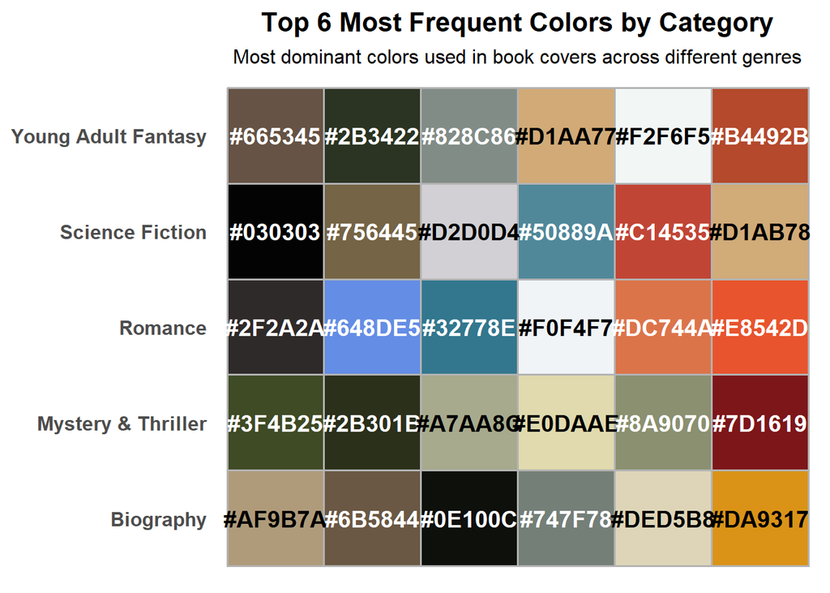

```r
# Ensure text color contrasts with background
top_colors_all <- top_colors_all %>%
  mutate(text_color = ifelse(
    (col2rgb(representative_color)[1,] * 0.299 +
     col2rgb(representative_color)[2,] * 0.587 +
     col2rgb(representative_color)[3,] * 0.114) > 150,
    "black", "white"
  ))


ggplot(top_colors_all, aes(x = factor(position), y = category, fill = representative_color)) +
    geom_tile(color = "gray70", linewidth = 0.7) +
    geom_text(aes(label = representative_color, color = text_color),
              size = 5, fontface = "bold") +
    scale_fill_identity() +
    scale_color_identity() +
    theme_minimal(base_size = 14) +
    labs(title = "Top 6 Most Frequent Colors by Category",
         subtitle = "Most dominant colors used in book covers across different genres",
         x = NULL, y = NULL) +
   theme(
    panel.background = element_rect(fill = "transparent", color = NA),
    plot.background = element_rect(fill = "transparent", color = NA),
    panel.grid = element_blank(),
    axis.text.x = element_blank(),
    axis.ticks = element_blank(),
    strip.text = element_text(face = "bold", size = 12),
    axis.text.y = element_text(face = "bold", size = 12),
    plot.title = element_text(face = "bold", size = 16, hjust = 0.5),
    plot.subtitle = element_text(size = 12, hjust = 0.5)
)
```

## Color representation per category and webpage

Furthermore, we repeated the previous analysis for each webpage, representing the color palette of each category per source. The comparative analysis reveals notable differences in color usage between the two platforms, indicating potential variations in design preferences, marketing strategies, or audience expectations.

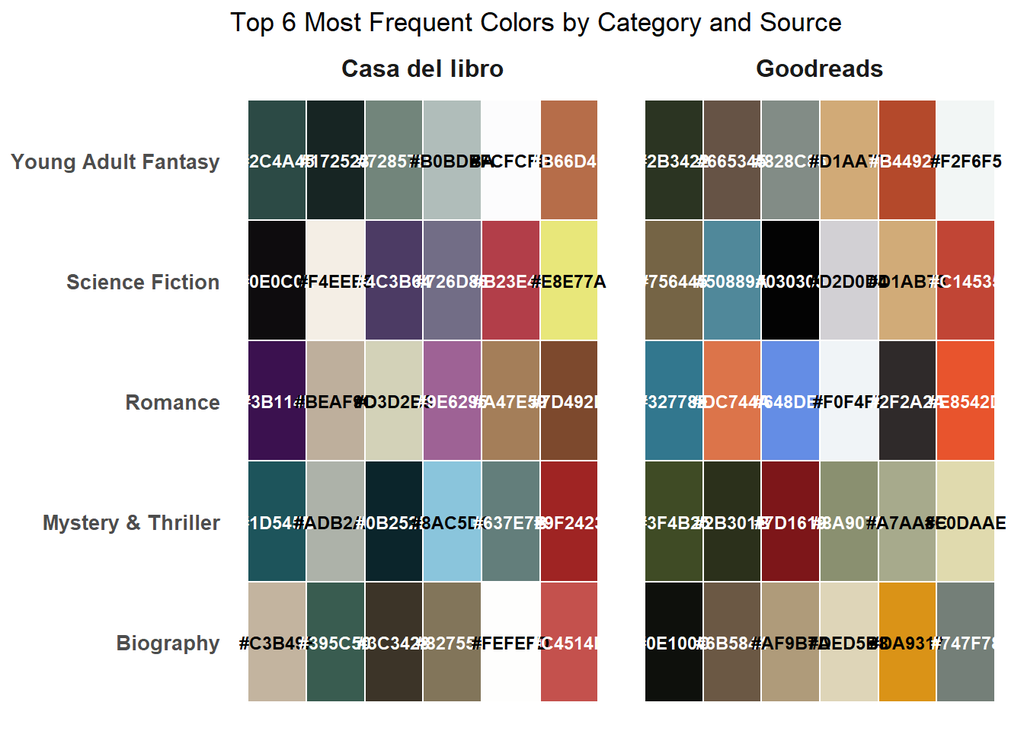

```r
cluster_representative <- color_data_clustered %>%
  group_by(category, cluster, webpage) %>%
  summarise(representative_color = first(hex))

best_books_clustered <- best_books_expanded %>%
    full_join(color_data_clustered, by = c("colors", "category", "title", "author", "webpage")) %>%
    full_join(cluster_representative, by = c("category", "cluster", "webpage"))

top_colors_all <- best_books_clustered %>%
  group_by(category, webpage, representative_color) %>%
  summarise(Freq = n(), .groups = "drop") %>%
  arrange(category, webpage, desc(Freq)) %>%  # Ensure webpage is considered
  group_by(category, webpage) %>%
  slice_head(n = 6) %>%
  mutate(position = row_number()) %>%
  ungroup() %>% mutate(text_color = ifelse(
    grepl("^#", representative_color),  # Ensure it's a hex color
    ifelse(
      (col2rgb(representative_color)[1,] * 0.299 +
       col2rgb(representative_color)[2,] * 0.587 +
       col2rgb(representative_color)[3,] * 0.114) > 150,
      "black", "white"
    ),
    "black"  # Default to black if invalid color
  ))


ggplot(top_colors_all, aes(x = position, y = category, fill = representative_color)) +
    geom_tile(color = "white", size = 0.5) +
    geom_text(aes(label = representative_color, color = text_color), size = 3, fontface = "bold") +
    scale_fill_identity() +
    scale_color_identity() +
    theme_minimal() +
    labs(title = "Top 6 Most Frequent Colors by Category and Source", x = NULL, y = NULL) +
    theme(
        axis.text.x = element_blank(),
        axis.ticks = element_blank(),
        panel.grid = element_blank(),
        strip.text = element_text(face = "bold", size = 12),
        axis.text.y = element_text(face = "bold", size = 10)
    ) +
    facet_wrap(~webpage)  # Should separate by webpage
```

# Shiny?

```r
library(shiny)
library(dplyr)
library(ggplot2)
library(tidyr)
library(stringr)


# UI
ui <- fluidPage(
  titlePanel("Colores Predominantes de Libros"),

  # Agregamos algo de CSS para mejorar el diseño
  tags$style(HTML("
    .filters-container {
      margin-bottom: 20px;
      padding: 10px;
      border: 1px solid #ddd;
      background-color: #f9f9f9;
      border-radius: 5px;
    }
    .color-rectangle {
      height: 25px;
      flex: 1 1 8.33%;  /* Ajustado a 8.33% para 12 rectángulos por fila */
      margin: 5px;
    }
    .color-boxes {
      display: flex;
      flex-wrap: wrap;  /* Permite que los rectángulos se acomoden en filas */
      justify-content: flex-start;  /* Alineación al inicio de la fila */
    }
  ")),

  # Estructura para los filtros
  fluidRow(
    column(12,
           div(class = "filters-container",
               # Filtro por categoría con opción "Todo"
               selectInput("category_select", "Selecciona una categoría:",
                           choices = c("Todo", unique(best_books_expanded$category)),
                           selected = "Todo"),

               # Filtro por webpage (opcional)
               selectInput("webpage_select", "Selecciona un webpage (opcional):",
                           choices = c("Todos", unique(best_books_expanded$webpage)),
                           selected = "Todos"),

               # Opción para elegir si se ven los colores predominantes
               checkboxInput("show_predominant", "Mostrar solo colores predominantes", value = FALSE)
           )
    )
  ),

  # Contenedor principal de los colores
  mainPanel(
    tabsetPanel(
      tabPanel("Colores",
               fluidRow(
                 # Mostrar los colores filtrados en rectángulos
                 uiOutput("color_display")
               )
      ),
      tabPanel("Colores Predominantes",
               plotOutput("color_plot")
      )
    )
  )
)

# Servidor
server <- function(input, output, session) {

  # Filtrar datos por categoría (y por webpage si se selecciona)
  filtered_data <- reactive({
    req(input$category_select)

    # Si se selecciona "Todo", no filtramos por categoría
    data <- best_books_expanded
    if (input$category_select != "Todo") {
      # Filtrar por categoría seleccionada
      data <- data %>%
        filter(category == input$category_select)
    }

    # Si selecciona un webpage específico, filtrar también por ese
    if (input$webpage_select != "Todos") {
      data <- data %>% filter(webpage == input$webpage_select)
    }

    if (input$show_predominant) {
      # Si se selecciona mostrar colores predominantes, filtrar por colores predominantes
      data <- data %>%
        group_by(category, colors) %>%
        summarise(Freq = n(), .groups = "drop") %>%
        arrange(desc(Freq))
    }

    return(data)
  })

  # Mostrar colores en forma de rectángulos
  output$color_display <- renderUI({
    data <- filtered_data()

    # Si no hay datos después del filtro
    if (nrow(data) == 0) {
      return(NULL)
    }

    # Crear un rectángulo por cada color
    color_elements <- lapply(1:nrow(data), function(i) {
      tags$div(
        class = "color-rectangle",
        style = paste("background-color:", data$colors[i], ";")
      )
    })

    # Devolver todos los rectángulos
    tags$div(class = "color-boxes", do.call(tagList, color_elements))
  })

  # Mostrar gráfico de colores predominantes
  output$color_plot <- renderPlot({
    data <- filtered_data()

    # Si no hay datos después del filtro
    if (nrow(data) == 0) {
      return(NULL)
    }

    # Crear un gráfico de barras para los colores predominantes
    ggplot(data, aes(x = colors, fill = colors)) +
      geom_bar() +
      scale_fill_identity() +  # Mostrar colores reales
      labs(title = "Colores Predominantes",
           x = "Color", y = "Frecuencia") +
      theme_minimal() +
      theme(axis.text.x = element_text(angle = 45, hjust = 1))
  })
}

# Ejecutar la app
shinyApp(ui = ui, server = server)
```

Shiny applications not supported in static R Markdown documents

Este es con imagenes solo

```r
library(shiny)
library(dplyr)

# Suponiendo que 'best_books' tiene las columnas: title, img_url, category, colors, author, webpage.

# UI
ui <- fluidPage(

  titlePanel("Comparación de Portadas de Libros"),

  # Filtros para seleccionar categoría y autor
  fluidRow(
    column(6,
           selectInput("category_select", "Selecciona una categoría:",
                       choices = c("Todo", unique(best_books$category)),
                       selected = "Todo")
    ),
    column(6,
           selectInput("author_select", "Selecciona un autor:",
                       choices = c("Todo"),
                       selected = "Todo")
    )
  ),

  # Mostrar las imágenes y colores filtrados
  mainPanel(
    fluidRow(
      # Crear espacio para mostrar las imágenes
      uiOutput("book_images")
    )
  )
)

# Server
server <- function(input, output, session) {

  # Filtrar los datos en función de las selecciones de categoría
  filtered_data <- reactive({
    data <- best_books

    # Filtrar por categoría
    if (input$category_select != "Todo") {
      data <- data %>% filter(category == input$category_select)
    }

    # Filtrar por autor
    if (input$author_select != "Todo") {
      data <- data %>% filter(author == input$author_select)
    }

    return(data)
  })

  # Actualizar el selectInput de autor basado en la categoría seleccionada
  observeEvent(input$category_select, {
    category_data <- filtered_data()

    # Actualizar los autores disponibles según la categoría seleccionada
    updateSelectInput(session, "author_select",
                      choices = c("Todo", unique(category_data$author)),
                      selected = "Todo")
  })

  # Mostrar las imágenes y paleta de colores según los filtros
  output$book_images <- renderUI({
    data <- filtered_data()

    # Si no hay resultados, mostrar un mensaje
    if (nrow(data) == 0) {
      return(tags$p("No se encontraron libros que coincidan con los filtros seleccionados."))
    }

    # Crear las imágenes de los libros
    image_elements <- lapply(1:nrow(data), function(i) {

      # Limpiar los colores y dividirlos en una lista
      colors_list <- strsplit(trimws(as.character(data$colors[i])), ",")[[1]]
      colors_list <- trimws(colors_list)  # Eliminar espacios innecesarios

      # Colores: Crear rectángulos para cada color predominante
      color_elements <- lapply(colors_list, function(color) {
        tags$div(
          style = paste("background-color:", color, "; width: 50px; height: 50px; display: inline-block; margin: 5px;")
        )
      })


      # Imagen del libro
      img_element <- tags$div(
        style = "display: inline-block; margin: 10px; text-align: center;",
        tags$img(src = data$img_url[i], width = "150px", height = "225px"),
        tags$div(style = "margin-top: 10px;", do.call(tagList, color_elements))
      )

      img_element
    })

    # Devolver el conjunto de imágenes y colores
    do.call(tagList, image_elements)
  })
}

# Ejecutar la aplicación
shinyApp(ui = ui, server = server)
```

Shiny applications not supported in static R Markdown documents

Este tiene barrita

```r
library(shiny)
library(dplyr)
library(scales)  # Para usar show_col

# Suponiendo que 'best_books' tiene las columnas: title, img_url, category, colors, author, webpage.

# UI
ui <- fluidPage(

  titlePanel("Comparación de Portadas de Libros"),

  # Filtros para seleccionar categoría y autor
  fluidRow(
    column(6,
           selectInput("category_select", "Selecciona una categoría:",
                       choices = c("Todo", unique(best_books$category)),
                       selected = "Todo")
    ),
    column(6,
           selectInput("author_select", "Selecciona un autor:",
                       choices = c("Todo"),
                       selected = "Todo")
    )
  ),

  # Mostrar las imágenes y colores filtrados
  mainPanel(
    fluidRow(
      # Crear espacio para mostrar las imágenes
      uiOutput("book_images")
    )
  )
)

# Server
server <- function(input, output, session) {

  # Filtrar los datos en función de las selecciones de categoría
  filtered_data <- reactive({
    data <- best_books

    # Filtrar por categoría
    if (input$category_select != "Todo") {
      data <- data %>% filter(category == input$category_select)
    }

    # Filtrar por autor
    if (input$author_select != "Todo") {
      data <- data %>% filter(author == input$author_select)
    }

    return(data)
  })

  # Actualizar el selectInput de autor basado en la categoría seleccionada
  observeEvent(input$category_select, {
    category_data <- filtered_data()

    # Actualizar los autores disponibles según la categoría seleccionada
    updateSelectInput(session, "author_select",
                      choices = c("Todo", unique(category_data$author)),
                      selected = "Todo")
  })

  # Mostrar las imágenes y paleta de colores según los filtros
  output$book_images <- renderUI({
    data <- filtered_data()

    # Si no hay resultados, mostrar un mensaje
    if (nrow(data) == 0) {
      return(tags$p("No se encontraron libros que coincidan con los filtros seleccionados."))
    }

    # Crear las imágenes de los libros
    image_elements <- lapply(1:nrow(data), function(i) {

      # Asegurarse de que la columna colors sea una lista de colores
      colors_list <- data$colors[[i]]

      # Verificar que los colores sean una lista
      if (is.list(colors_list)) {
        colors_list <- unlist(colors_list)  # Convertir lista en un vector
      }

      # Mostrar la paleta de colores como una barra de colores
      color_bar <- tags$div(
        style = paste("background: linear-gradient(to right, ", paste(colors_list, collapse = ", "), "); height: 20px; width: 100%; margin-top: 10px;")
      )

      # Imagen del libro
      img_element <- tags$div(
        style = "display: inline-block; margin: 10px; text-align: center;",
        tags$img(src = data$img_url[i], width = "150px", height = "225px"),
        color_bar
      )

      img_element
    })

    # Devolver el conjunto de imágenes y colores
    do.call(tagList, image_elements)
  })
}

# Ejecutar la aplicación
shinyApp(ui = ui, server = server)
```

Shiny applications not supported in static R Markdown documents

Con cuadraditos

```r
library(shiny)
library(dplyr)
library(scales)  # Para usar show_col

# Suponiendo que 'best_books' tiene las columnas: title, img_url, category, colors, author, webpage.

# UI
ui <- fluidPage(

  titlePanel("Comparación de Portadas de Libros"),

  # Filtros para seleccionar categoría y autor
  fluidRow(
    column(6,
           selectInput("category_select", "Selecciona una categoría:",
                       choices = c("Todo", unique(best_books$category)),
                       selected = "Todo")
    ),
    column(6,
           selectInput("author_select", "Selecciona un autor:",
                       choices = c("Todo"),
                       selected = "Todo")
    )
  ),

  # Mostrar las imágenes y colores filtrados
  mainPanel(
    fluidRow(
      # Crear espacio para mostrar las imágenes
      uiOutput("book_images")
    )
  )
)

# Server
server <- function(input, output, session) {

  # Filtrar los datos en función de las selecciones de categoría
  filtered_data <- reactive({
    data <- best_books

    # Filtrar por categoría
    if (input$category_select != "Todo") {
      data <- data %>% filter(category == input$category_select)
    }

    # Filtrar por autor
    if (input$author_select != "Todo") {
      data <- data %>% filter(author == input$author_select)
    }

    return(data)
  })

  # Actualizar el selectInput de autor basado en la categoría seleccionada
  observeEvent(input$category_select, {
    category_data <- filtered_data()

    # Actualizar los autores disponibles según la categoría seleccionada
    updateSelectInput(session, "author_select",
                      choices = c("Todo", unique(category_data$author)),
                      selected = "Todo")
  })

  # Mostrar las imágenes y paleta de colores según los filtros
  output$book_images <- renderUI({
    data <- filtered_data()

    # Si no hay resultados, mostrar un mensaje
    if (nrow(data) == 0) {
      return(tags$p("No se encontraron libros que coincidan con los filtros seleccionados."))
    }

    # Crear las imágenes de los libros
    image_elements <- lapply(1:nrow(data), function(i) {

      # Asegurarse de que la columna colors sea una lista de colores
      colors_list <- data$colors[[i]]

      # Verificar que los colores sean una lista
      if (is.list(colors_list)) {
        colors_list <- unlist(colors_list)  # Convertir lista en un vector
      }

      # Crear los tiles de colores (pequeños bloques de color)
      color_tiles <- lapply(colors_list, function(color) {
        tags$div(
          style = paste("background-color:", color, "; width: 30px; height: 30px; display: inline-block; margin-right: 5px;")
        )
      })

      # Imagen del libro
      img_element <- tags$div(
        style = "display: inline-block; margin: 10px; text-align: center;",
        tags$img(src = data$img_url[i], width = "150px", height = "225px"),
        tags$div(style = "margin-top: 10px;", do.call(tagList, color_tiles))  # Mostrar los tiles de colores
      )

      img_element
    })

    # Devolver el conjunto de imágenes y colores
    do.call(tagList, image_elements)
  })
}

# Ejecutar la aplicación
shinyApp(ui = ui, server = server)
```

Shiny applications not supported in static R Markdown documents

combined

```r
library(shiny)
library(dplyr)
library(scales)  # Para usar show_col

# Suponiendo que 'best_books' tiene las columnas: title, img_url, category, colors, author, webpage.

# UI
ui <- fluidPage(

  titlePanel("Comparación de Portadas de Libros"),

  # Filtros para seleccionar categoría y autor
  fluidRow(
    column(6,
           selectInput("category_select", "Selecciona una categoría:",
                       choices = c("Todo", unique(best_books$category)),
                       selected = "Todo")
    ),
    column(6,
           selectInput("author_select", "Selecciona un autor:",
                       choices = c("Todo"),
                       selected = "Todo")
    )
  ),

  # Mostrar las imágenes y colores filtrados
  mainPanel(
    fluidRow(
      # Crear espacio para mostrar las imágenes
      uiOutput("book_images")
    )
  )
)

# Server
server <- function(input, output, session) {

  # Filtrar los datos en función de las selecciones de categoría
  filtered_data <- reactive({
    data <- best_books

    # Filtrar por categoría
    if (input$category_select != "Todo") {
      data <- data %>% filter(category == input$category_select)
    }

    # Filtrar por autor
    if (input$author_select != "Todo") {
      data <- data %>% filter(author == input$author_select)
    }

    return(data)
  })

  # Actualizar el selectInput de autor basado en la categoría seleccionada
  observeEvent(input$category_select, {
    category_data <- filtered_data()

    # Actualizar los autores disponibles según la categoría seleccionada
    updateSelectInput(session, "author_select",
                      choices = c("Todo", unique(category_data$author)),
                      selected = "Todo")
  })

  # Mostrar las imágenes y paleta de colores según los filtros
  output$book_images <- renderUI({
    data <- filtered_data()

    # Si no hay resultados, mostrar un mensaje
    if (nrow(data) == 0) {
      return(tags$p("No se encontraron libros que coincidan con los filtros seleccionados."))
    }

    # Crear las imágenes de los libros
    image_elements <- lapply(1:nrow(data), function(i) {

      # Asegurarse de que la columna colors sea una lista de colores
      colors_list <- data$colors[[i]]

      # Verificar que los colores sean una lista
      if (is.list(colors_list)) {
        colors_list <- unlist(colors_list)  # Convertir lista en un vector
      }

      # Crear los tiles de colores (pequeños bloques de color)
      color_tiles <- lapply(colors_list, function(color) {
        tags$div(
          style = paste("background-color:", color, "; width: 30px; height: 30px; display: inline-block; margin-right: 5px;")
        )
      })

      # Mostrar la paleta de colores como una barra de colores
      color_bar <- tags$div(
        style = paste("background: linear-gradient(to right, ", paste(colors_list, collapse = ", "), "); height: 20px; width: 100%; margin-top: 10px;")
      )

      # Imagen del libro centrada
      img_element <- tags$div(
        style = "display: inline-block; text-align: center; margin: 10px;",  # Centrar la imagen
        tags$img(src = data$img_url[i], width = "150px", height = "225px")
      )

      # Crear un div para contener la imagen, los bloques de colores y la barra de colores
      combined_element <- tags$div(
        style = "display: flex; flex-direction: column; align-items: center; margin: 20px;",
        # Contenedor para la imagen centrada y los bloques de colores al lado
        tags$div(
          style = "display: flex; align-items: center; justify-content: center; margin-bottom: 10px;",
          img_element,  # Imagen
          do.call(tagList, color_tiles)  # Cuadrados de colores
        ),
        color_bar  # Barra de colores debajo
      )

      combined_element
    })

    # Devolver el conjunto de imágenes y colores
    do.call(tagList, image_elements)
  })
}

# Ejecutar la aplicación
shinyApp(ui = ui, server = server)
```

Shiny applications not supported in static R Markdown documents

# Top author

In addition, we identified the most frequently occurring colors in the book covers of the most prolific author in the dataset and visualized the color palette. The script first determines the top author based on the number of books, then extracts the six most dominant colors from their book covers and each color is displayed as a tile in a bar-like palette, with contrasting text labels for readability.

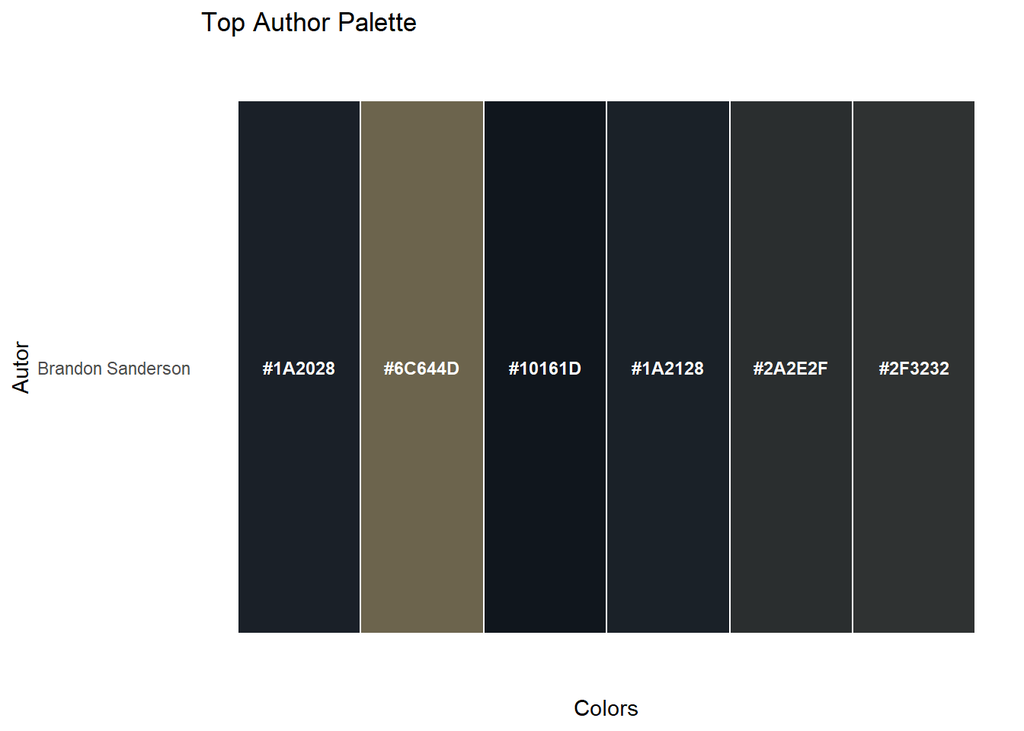

```r
top_author <- best_books %>%
    count(author, sort = TRUE) %>%
    arrange(desc(n)) %>%
    slice(1) %>%
    pull(author) %>%
    .[[1]]  # Force extraction of only the first element


top_authors_colors <- best_books %>%
    filter(author == top_author) %>%
    unnest_longer(colors) %>%
    count(author, colors, sort = TRUE) %>%
    slice_head(n = 6) %>%
    mutate(rank = row_number()) %>%
    ungroup() %>% mutate(text_color = ifelse(
    grepl("^#", colors),  # Ensure it's a hex color
    ifelse(
      (col2rgb(colors)[1,] * 0.299 +
       col2rgb(colors)[2,] * 0.587 +
       col2rgb(colors)[3,] * 0.114) > 150,
      "black", "white"
    ),
    "black"  # Default to black if invalid color
  ))

ggplot(top_authors_colors, aes(x = rank, y = reorder(author, -n), fill = colors)) +
    geom_tile(color = "white", size = 0.5) +
    geom_text(aes(label = colors, color = text_color), size = 3, fontface = "bold") +
    scale_fill_identity() +
    scale_color_identity() +
    theme_minimal() +
    labs(title = "Top Author Palette",
         x = "Colors", y = "Autor") +
    theme(axis.text.x = element_blank(),
          axis.ticks.x = element_blank(),
          panel.grid = element_blank())
```

# Top 5 authors

[figure not shown]

```r
top_authors <- best_books %>%
    count(author, sort = TRUE) %>%
    arrange(desc(n)) %>%
    slice(1) %>%
    pull(author) %>%
    head(5)  # Keep only the first 5 elements


top_authors_colors <- best_books %>%
    filter(author %in% top_authors) %>%
    unnest_longer(colors) %>%
    count(author, category, colors, sort = TRUE) %>%
    group_by(author, category) %>%
    slice_head(n = 6) %>%
    mutate(rank = row_number()) %>%
    ungroup() %>%
    mutate(author_label = paste0(author, " (", category, ")")) %>%
    mutate(text_color = ifelse(
        grepl("^#", colors),
        ifelse(
            (col2rgb(colors)[1,] * 0.299 +
             col2rgb(colors)[2,] * 0.587 +
             col2rgb(colors)[3,] * 0.114) > 150,
            "black", "white"
        ),
        "black"
    ))


ggplot(top_authors_colors, aes(x = rank, y = reorder(author_label, -n), fill = colors)) +
    geom_tile(color = "gray", size = 0.5) +
    geom_text(aes(label = colors, color = text_color), size = 3, fontface = "bold") +
    scale_fill_identity() +
    scale_color_identity() +
    theme_minimal() +
    labs(title = "Top 6 Colors for the 5 Most Prolific Authors",
         x = "Colors", y = "Author (Category)") +
    theme(axis.text.x = element_blank(),
          axis.ticks.x = element_blank(),
          panel.grid = element_blank())
```

Here it can be observed that the color palettes used by different authors show significant variation without a clear pattern.

This visualization provides insights into the color trends associated with an author’s book covers, which can be useful for design analysis and trend exploration.

## Authors palette

To examine each author’s palette, we developed a shiny app that allows users to explore the most dominant colors used in book covers for different authors. Thus, an author can be selected from a dropdown menu, and the app generates a color palette visualization displaying the top six most frequent colors found in their book covers. Additionally, a separate tab showcases the book cover images, giving a visual representation of the author’s works.

```r
ui <- fluidPage(
    titlePanel("Book Cover Color Analysis"),

    sidebarLayout(
        sidebarPanel(
            selectInput("author", "Select an Author:", choices = unique(best_books$author))
        ),

        mainPanel(
            tabsetPanel(
                tabPanel("Color Palette", plotOutput("colorPlot")),
                tabPanel("Book Covers", uiOutput("bookImages"))
            )
        )
    )
)

# Server
server <- function(input, output) {

    # Filter books based on selected author
    filtered_books <- reactive({
        best_books %>% filter(author == input$author)
    })

    # Generate color palette plot
    output$colorPlot <- renderPlot({
        data <- filtered_books() %>%
            unnest_longer(colors) %>%
            count(author, colors, sort = TRUE) %>%
            slice_head(n = 6) %>%
            mutate(rank = row_number()) %>%
            ungroup() %>%
            mutate(text_color = ifelse(
                (col2rgb(colors)[1,] * 0.299 +
                 col2rgb(colors)[2,] * 0.587 +
                 col2rgb(colors)[3,] * 0.114) > 150,
                "black", "white"
            ))

        ggplot(data, aes(x = rank, y = reorder(author, -n), fill = colors)) +
            geom_tile(color = "white", size = 0.5) +
            geom_text(aes(label = colors, color = text_color), size = 5, fontface = "bold") +
            scale_fill_identity() +
            scale_color_identity() +
            theme_minimal() +
            labs(title = "Top Colors for Selected Author",
                 x = "Rank", y = "Author") +
            theme(axis.text.x = element_blank(),
                  axis.ticks.x = element_blank(),
                  panel.grid = element_blank())
    })

    # Display book cover images
    output$bookImages <- renderUI({
        books <- filtered_books()
        img_tags <- lapply(books$img_url, function(url) {
            tags$img(src = url, width = "100px", style = "margin: 5px;")
        })
        do.call(tagList, img_tags)
    })
}

# Run the app
shinyApp(ui = ui, server = server)
```

Shiny applications not supported in static R Markdown documents

# Conclusions

The analysis of book cover colors across authors, genres, and platforms reveals no strict pattern but rather a dynamic interplay of artistic choices. While certain genres tend to favor specific color schemes —such as dark and cool tones for Young Adult Fantasy— there is considerable variation between platforms. Similarly, individual authors exhibit unique palettes, but there is no single defining scheme that dominates across their works.

These findings suggest that book cover design is influenced by multiple factors beyond just genre or author branding, including publisher strategies, regional aesthetics, and reader preferences. The divergence in colors across platforms further implies that book marketing is tailored to different audiences, with some covers emphasizing vibrancy while others adopt more sophisticated tones. Ultimately, it can be concluded that visual identity is shaped by both artistic vision and market-driven considerations.